# CE2 Mathematics: Probability & Statistics 2018

# Lecture 1 - Course Overview and Chapter 1

## Sections 1.1-1.4

### To launch the notebook:

- From the menu above, select `Kernel` and `Restart & Run All`.
- Make sure that the `%matplotlib inline` and `%run Codes/Lecture01.ipy` cells were executed without an error. A number will appear to the left of each (e.g. `In [1]`) if successful.
- If you prefer to follow the lecture in slide format, select the Lecture Overview cell and click on the RISE button in the menu above

### Solutions to worked problems during lecture:

- The answers are encoded by passwords; the information regarding the format of the password can be found by hovering your mouse over the icon
- Type your answer within the quotes in `password''`, then type `Shift` and `Enter` (or click the `>| Run` button above). If you get it correct, the full solution will be displayed. If the answer is incorrect, a random string of text will appear.

```python
%matplotlib inline
```

```python
%run Codes/Lecture01.ipy
```

## Lecture Overview

- 1.1 **Basic Definitions** (Outcomes, Events, Sample Spaces)
- 1.2 **Basic Set Theory using Events**
- 1.3 **General Laws and Axioms of Probability**
- Introduce Some **Key Probability Relationships**
  - 1.3 **Inclusion-Exclusion**
  - 1.4 **Conditional Probability**

## 1.1 Basic Definitions

- An **Experiment** is any procedure than can be repeated any number of times (theoretically infinitely), and has a well-defined set of potential Outcomes.
- An **Outcome**, $\omega$, is a potential eventuality of an Experiment.
- The **Sample Space** or ‘universe’, denoted by $\Omega$, is the set of all possible outcomes ($\omega$) of the experiment. An outcome is a member of the sample space, so we can write $\omega \in \Omega$.
- An **Event** $A$ is some subset of $\Omega$, $A \subseteq \Omega$. An elementary event is one which only contains a single outcome.

## 1.1 Event Example

**Events for Dice**: The sample space for a dice roll contains six outcomes, i.e. $\Omega_{\text{dice}} = {1, 2, 3, 4, 5, 6}$. We can describe three events $A$, $B$ and $C$ as follows:

- Event $A$ - the rolled number is equal to 6;
- Event $B$ - the rolled number is odd;
- Event $C$ - the rolled number is greater than 3;

Each of these events would then correspond to one or more outcomes in $\Omega_\text{dice}$, namely:

$A = {6} \qquad B = {1, 3, 5} \qquad C = {4, 5, 6}$

```python
display(HBox([query]+d_list, layout = Layout(display = 'flex', align_items = 'center')))
```

## 1.2 Set Theory for Describing Events

- The **union** of $A$ and $B$, denoted $A \cup B$, is the set of those outcomes which belong to $A$ or $B$ (or both).
  - $A \cup B$ occurs if $A$ occurs or $B$ occurs (or they both occur).
- The **intersection** of $A$ and $B$, denoted $A \cap B$, is the set of those outcomes which belong to both $A$ and $B$.
  - $A \cap B$ occurs if $A$ occurs and $B$ occurs.
- The **complement** of $A$, denoted $\overline A$, is the set of those outcomes which do not belong to $A$.
  - $\overline A$ occurs if $A$ does not occur.

## 1.2 Venn Diagrams: Event Representation

[figure not shown]

## 1.2 Note: Subtle Change in Nomenclature

**NOTE**: At this point, we are going to adopt another notation for the **intersection** of two sets. $\color{red}{(A \cap B)}$ is frequently used in the *set theory* calculations described above. However, in applications of *probability theory*, this is more commonly represented as $\color{blue}{(A, B)}$, which corresponds to a *multivariate* distribution of two random variables (a subject of importance that will be further explored in subsequent chapters, but for now just note the change in notation).

Long story short: $\color{red}{(A \cap B)}$ will be represented as $\color{blue}{(A, B)}$ from now on when talking about Probabilities.

## 1.3 Probability Associated with Events

- Original definitions arose within the context of gambling, or situations where $n$ possible outcomes were equally likely. If some event $A$ were satisfied by $m$ outcomes, then $P(A) = \frac{m}{n}$ (this is the *classical* or *a priori* definition of probability, which we will encounter in subsequent examples).
- However, what if outcomes are not equally likely, or occupy an infinite space? We could then resort to an *empirical* or *a posteriori* definition of probability, where we repeat an experiment *n* times; this method can also suffer from limitations...
- Due to these issues, there was a strong desire to define probability as a *function* rather than a ratio (or limit).

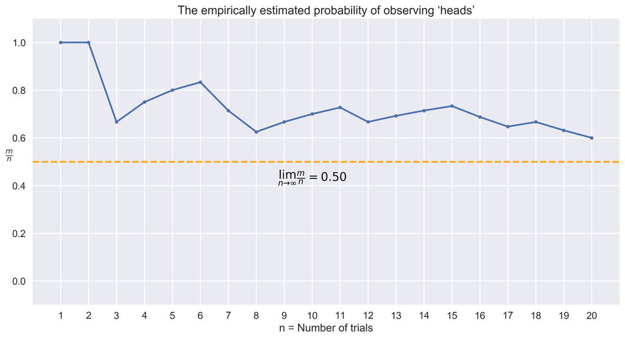

```
<function __main__.l1_coin_trials(n, p)>
```

```python
wgt.interact(l1_coin_trials, n=wgt.IntText(value=20, description='Number of trials:', disabled=False, style={'description_width': '170px'}), p=wgt.FloatSlider(min=0.01, max=0.99, step=0.01, value=0.50, layout=Layout(width='50%'), continuous_update=False, description='The probability of HEAD (p):', style={'description_width': '170px'}))
```

## 1.3 Axioms of Probability

| 1st axiom | $$P(A) \in \mathbb R$$ $$\color{blue}{0 \leq P(A) \leq 1}$$ | The probability of an event A is a real number between 0 and 1. |
| --- | --- | --- |
| 2nd axiom | $$P(\Omega) = 1$$ | The certain event has probability 1. |
| 3rd axiom | $$\text{If } A \cap B = \emptyset$$ $$\text{then } P(A \cup B) = P(A)+P(B)$$ $$\text{and } \color{blue}{P(\bigcup_{i=1}^{n} A_i) = \sum_{i=1}^{n} P(A_i)}$$ | The probability of the union of disjoint events is equal to the sum of their probabilities. |

*Comment on 3rd Axiom: What if $A \cap B \neq \emptyset$?* (*See below*)

## 1.3 From Axioms Derive Fundamental Properties

**P1**: $P(\overline A) = 1 - P(A)$

**P2**: $P(\emptyset) = 0$

**P3**: If $A \subset B$ then $P(A) \leq P(B)$

**P4**: $P(A \cup B) = P(A) + P(B) - P(A, B)$ (The inclusion-exclusion formula)

## 1.3 P4: The Inclusion-Exclusion Formula

[figure not shown]

$$P(A \cup B) = P(A) + P(B) - P(A, B)$$

**Mentimeter Poll**: [76 62 56](https://www.menti.com/afaeb964) (Click to open in browser)

#### Download the survey results by running the cell below

```python
results = menti_results("f5572005f474")
Ω,B,G,BG,N = sum(results.values()), results['Breaking Bad'], results['Game of Thrones'], results['Both'], results['Neither']
```

## 1.3 P4: The Inclusion-Exclusion Formula: Example

```python
Markdown('In an online survey of ${}$ students, ${}$ students claimed to have seen the **Breaking Bad** TV series. The survey has also revealed that ${}$ students watch *Game of Thrones*, out of which ${}$ students watched both shows. What is the probability that a randomly-selected student has seen neither of the two shows?'.format(Ω,B,G,BG))
```

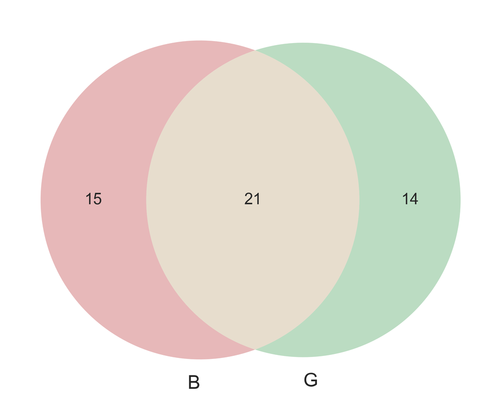

```python
venn2(subsets=(B,G,BG), set_labels=('B', 'G'));
```

```python
Latex(r'''\begin{{align}}
          \Omega &= \text{{({}) students in the survey}} \\\
          B &= \text{{({}) students who watch }} \textit{{Breaking Bad}} \\\
          G &= \text{{({}) students who watch }} \textit{{Game of Thrones}} \\\
          (B,G) &= \text{{({}) students who watch both}} \\\
          N &= \text{{({}) students who watch neither}}
          \end{{align}}
         '''.format(Ω, B+BG, G+BG, BG, N))
```

\begin{align} \Omega &= \text{(104) students in the survey} \\\ B &= \text{(36) students who watch } \textit{Breaking Bad} \\\ G &= \text{(35) students who watch } \textit{Game of Thrones} \\\ (B,G) &= \text{(21) students who watch both} \\\ N &= \text{(54) students who watch neither} \end{align}

## 1.4 Conditional Probability

- Let $A$ and $B$ be events with $P(B) > 0$. The **conditional probability** $P(A|B)$ (probability of $A$ *given* $B$) is defined as:

$$P(A|B) = \frac{\color{red}{P(A,B)}}{\color{grey}{P(B)}}$$

- This represents the probability that $A$ with occur given that $B$ has occured.
- *Start by thinking about what $P(A,B)$ in the numerator is first...*

[figure not shown]

## 1.4 Conditional Probability: Example

- What is the probability that a person has seen *Game of Thrones*, given that said person is a *Breaking Bad* fan?
- We want to find $P(G|B)$ $$P(G|B) = \frac{\color{red}{P(G,B)}}{\color{grey}{P(B)}}$$
- Note that this probability is the same as the probability of selecting a *Game of Thrones* viewer at random from the list of *Breaking Bad* viewers. Conditional probabilities can be thought to be reducing the sample space to outcomes satisfied by the conditioned event only.

```python
Math(r'P(G|B) = {}'.format(BG/(B+BG)))
```

$$P(G|B) = 0.5833333333333334$$

**Mentimeter**: [59 62 86](https://www.menti.com/0928641b) (Click to open in browser)